# Feature Selection2

Muhammet Fatih ANAÇ

2024-07-31

## Veri Setinin Yüklenmesi

```r
file_path <- file.choose()
veri <- read.csv(file_path)
head(veri)
```

```
##   age workclass fnlwgt    education educational.num     marital.status
## 1  25   Private 226802         11th               7      Never-married
## 2  38   Private  89814      HS-grad               9 Married-civ-spouse
## 3  28 Local-gov 336951   Assoc-acdm              12 Married-civ-spouse
## 4  44   Private 160323 Some-college              10 Married-civ-spouse
## 5  18         ? 103497 Some-college              10      Never-married
## 6  34   Private 198693         10th               6      Never-married
##          occupation  relationship  race gender capital.gain capital.loss
## 1 Machine-op-inspct     Own-child Black   Male            0            0
## 2   Farming-fishing       Husband White   Male            0            0
## 3   Protective-serv       Husband White   Male            0            0
## 4 Machine-op-inspct       Husband Black   Male         7688            0
## 5                 ?     Own-child White Female            0            0
## 6     Other-service Not-in-family White   Male            0            0
##   hours.per.week native.country income
## 1             40  United-States  <=50K
## 2             50  United-States  <=50K
## 3             40  United-States   >50K
## 4             40  United-States   >50K
## 5             30  United-States  <=50K
## 6             30  United-States  <=50K
```

```r
summary(veri)
```

```
##       age         workclass             fnlwgt         education
##  Min.   :17.00   Length:48842       Min.   :  12285   Length:48842
##  1st Qu.:28.00   Class :character   1st Qu.: 117551   Class :character
##  Median :37.00   Mode  :character   Median : 178145   Mode  :character
##  Mean   :38.64                      Mean   : 189664
##  3rd Qu.:48.00                      3rd Qu.: 237642
##  Max.   :90.00                      Max.   :1490400
##  educational.num marital.status      occupation        relationship
##  Min.   : 1.00   Length:48842       Length:48842       Length:48842
##  1st Qu.: 9.00   Class :character   Class :character   Class :character
##  Median :10.00   Mode  :character   Mode  :character   Mode  :character
##  Mean   :10.08
##  3rd Qu.:12.00
##  Max.   :16.00
##      race              gender           capital.gain    capital.loss
##  Length:48842       Length:48842       Min.   :    0   Min.   :   0.0
##  Class :character   Class :character   1st Qu.:    0   1st Qu.:   0.0
##  Mode  :character   Mode  :character   Median :    0   Median :   0.0
##                                        Mean   : 1079   Mean   :  87.5
##                                        3rd Qu.:    0   3rd Qu.:   0.0
##                                        Max.   :99999   Max.   :4356.0
##  hours.per.week  native.country        income
##  Min.   : 1.00   Length:48842       Length:48842
##  1st Qu.:40.00   Class :character   Class :character
##  Median :40.00   Mode  :character   Mode  :character
##  Mean   :40.42
##  3rd Qu.:45.00
##  Max.   :99.00
```

#### age ve hours.per.week değişkenlerinin sayısal değişkenler olduğu anlaşılıyor. Bilgi kaybı olmaması için bu değişkeler kategorik hale getirilip kullanılabilir. workclass ve occupation değişkenlerinde “?” değerleri olduğu için eksik gözlemlerin “?” olarak girildiği anlaşılıyor. Bu durumları düzeltmek için:

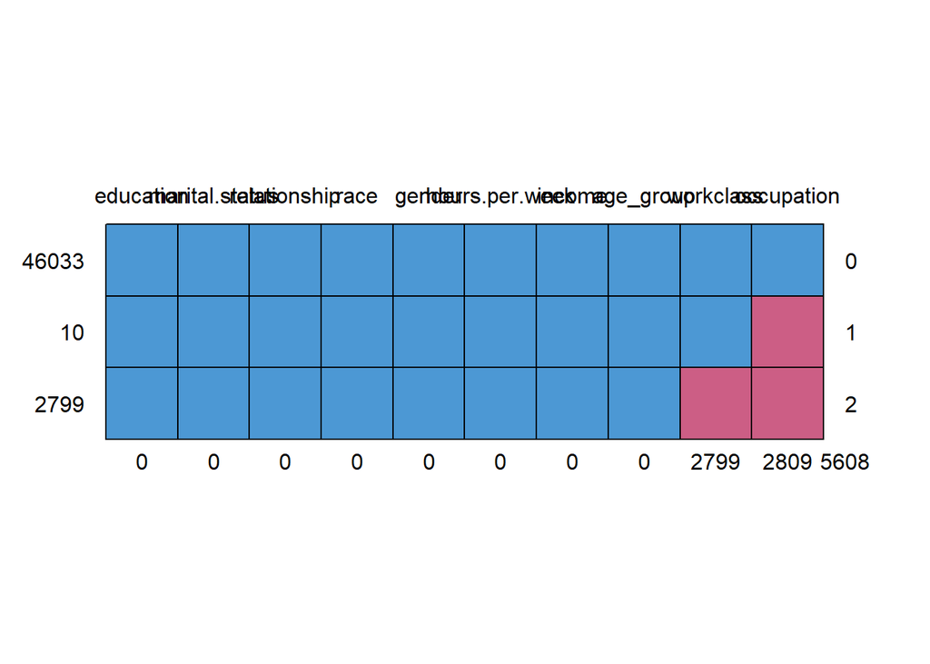

```
##       education marital.status relationship race gender hours.per.week income
## 46033         1              1            1    1      1              1      1
## 10            1              1            1    1      1              1      1
## 2799          1              1            1    1      1              1      1
##               0              0            0    0      0              0      0
##       age_group workclass occupation
## 46033         1         1          1    0
## 10            1         1          0    1
## 2799          1         0          0    2
##               0      2799       2809 5608
```

```r
library(mice)

veri$age_group <- cut(veri$age, breaks = c(0, 30, 60, 90), labels = c('0-30', '31-60', '61-90'))
veri<-veri[,-c(1,3)]
veri<-veri[,-c(9,10)]
veri$hours.per.week <- cut(veri$hours.per.week, breaks = c(0, 33, 66, 99), labels = c('0-32', '33-65', '66-99'))
veri<-veri[,-3]

veri$workclass[veri$workclass=="?"]<-NA
veri$occupation[veri$occupation=="?"]<-NA
veri<-veri[,-9]

veri$workclass<-factor(veri$workclass)
veri$education<-factor(veri$education)
veri$marital.status<-factor(veri$marital.status)
veri$occupation<-factor(veri$occupation)
veri$relationship<-factor(veri$relationship)
veri$race<-factor(veri$race)
veri$gender<-factor(veri$gender)
veri$hours.per.week<-factor(veri$hours.per.week)
veri$income<-factor(veri$income)
veri$age_group<-factor(veri$age_group)


md.pattern(veri)
```

#### Veri setinde 5608 tane eksik değer var. Bunların 2799’u workclass değişkeninde, 2809’u occupation değişkeninde. Veri setinde toplam 48842 gözlem olduğu için eksik değerler doldurulabilir.

```r
set.seed(123)
imputed<-mice(veri, m=1)
```

[output not shown]

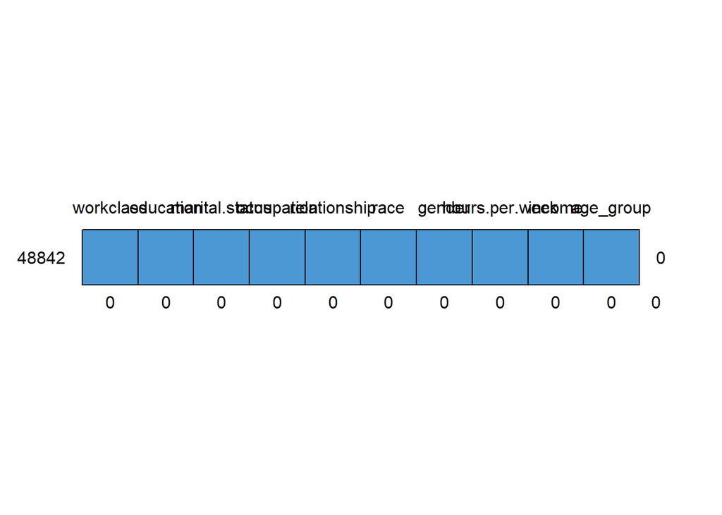

```
##       workclass education marital.status occupation relationship race gender
## 48842         1         1              1          1            1    1      1
##               0         0              0          0            0    0      0
##       hours.per.week income age_group
## 48842              1      1         1 0
##                    0      0         0 0
```

```r
veri_imp<-complete(imputed, 1)
md.pattern(veri_imp)
```

#### Veri setinde eksik gözlem kalmadı.

## Veriyi Eğitim ve Test Verisi Olarak Ayırma

```r
veri_imp_greater<-veri_imp[veri_imp$income==">50K", ]
veri_imp_less<-veri_imp[veri_imp$income=="<=50K", ]

set.seed(123)
veri_imp_greater_index<-sample(1:nrow(veri_imp_greater), size = 0.75*nrow(veri_imp_greater))

set.seed(123)
veri_imp_less_index<-sample(1:nrow(veri_imp_less), size = 0.75*nrow(veri_imp_less))


train_greater<-veri_imp_greater[veri_imp_greater_index, ]
train_less<-veri_imp_less[veri_imp_less_index, ]

train<-rbind(train_greater, train_less)

test_greater<-veri_imp_greater[-veri_imp_greater_index, ]
test_less<-veri_imp_less[-veri_imp_less_index, ]

test<-rbind(test_greater, test_less)
```

## Lojistik Regresyon Modeli

```r
train$income <- relevel(train$income, ref = "<=50K")
log_model<-glm(income~., family = "binomial", data=train)
summary(log_model)
```

```
##
## Call:
## glm(formula = income ~ ., family = "binomial", data = train)
##
## Deviance Residuals:
##     Min       1Q   Median       3Q      Max
## -2.4002  -0.5537  -0.2089  -0.0349   3.7465
##
## Coefficients:
##                                     Estimate Std. Error z value Pr(>|z|)
## (Intercept)                         -6.77106    0.36221 -18.694  < 2e-16 ***
## workclassLocal-gov                  -0.55652    0.10005  -5.562 2.66e-08 ***
## workclassNever-worked               -9.21215   71.66666  -0.129  0.89772
## workclassPrivate                    -0.34121    0.08334  -4.094 4.24e-05 ***
## workclassSelf-emp-inc                0.03005    0.10776   0.279  0.78038
## workclassSelf-emp-not-inc           -0.73270    0.09752  -7.513 5.77e-14 ***
## workclassState-gov                  -0.80429    0.11023  -7.296 2.96e-13 ***
## workclassWithout-pay                -1.19375    0.80531  -1.482  0.13825
## education11th                        0.03506    0.19010   0.184  0.85367
## education12th                        0.23677    0.23947   0.989  0.32279
## education1st-4th                    -1.55806    0.60537  -2.574  0.01006 *
## education5th-6th                    -0.45246    0.29014  -1.559  0.11890
## education7th-8th                    -0.40251    0.20934  -1.923  0.05451 .
## education9th                        -0.29434    0.23308  -1.263  0.20667
## educationAssoc-acdm                  1.32642    0.15716   8.440  < 2e-16 ***
## educationAssoc-voc                   1.23538    0.15204   8.125 4.46e-16 ***
## educationBachelors                   1.87488    0.14086  13.310  < 2e-16 ***
## educationDoctorate                   3.04323    0.19362  15.717  < 2e-16 ***
## educationHS-grad                     0.76641    0.13740   5.578 2.43e-08 ***
## educationMasters                     2.24518    0.15007  14.961  < 2e-16 ***
## educationPreschool                  -1.36166    1.03100  -1.321  0.18659
## educationProf-school                 2.93700    0.17868  16.438  < 2e-16 ***
## educationSome-college                1.15336    0.13935   8.277  < 2e-16 ***
## marital.statusMarried-AF-spouse      3.03094    0.51115   5.930 3.04e-09 ***
## marital.statusMarried-civ-spouse     2.32819    0.24161   9.636  < 2e-16 ***
## marital.statusMarried-spouse-absent  0.34163    0.17748   1.925  0.05425 .
## marital.statusNever-married         -0.31985    0.07538  -4.243 2.20e-05 ***
## marital.statusSeparated             -0.07360    0.13915  -0.529  0.59683
## marital.statusWidowed                0.40877    0.13127   3.114  0.00185 **
## occupationArmed-Forces               1.42633    0.91130   1.565  0.11755
```

[output cut: 21 more lines]

```
## genderMale                           0.78745    0.06755  11.657  < 2e-16 ***
## hours.per.week33-65                  1.12871    0.06607  17.083  < 2e-16 ***
## hours.per.week66-99                  1.23856    0.10804  11.464  < 2e-16 ***
## age_group31-60                       1.09593    0.04854  22.580  < 2e-16 ***
## age_group61-90                       0.91954    0.07662  12.001  < 2e-16 ***
## ---
## Signif. codes:  0 '***' 0.001 '**' 0.01 '*' 0.05 '.' 0.1 ' ' 1
##
## (Dispersion parameter for binomial family taken to be 1)
##
##     Null deviance: 40312  on 36630  degrees of freedom
## Residual deviance: 25384  on 36575  degrees of freedom
## AIC: 25496
##
## Number of Fisher Scoring iterations: 11
```

## Katsayıların (Odds Oranlarının) İncelenmesi

```r
exp(coef(log_model))
```

```
##                         (Intercept)                  workclassLocal-gov
##                        1.146479e-03                        5.731997e-01
##               workclassNever-worked                    workclassPrivate
##                        9.981921e-05                        7.109127e-01
##               workclassSelf-emp-inc           workclassSelf-emp-not-inc
##                        1.030503e+00                        4.806096e-01
##                  workclassState-gov                workclassWithout-pay
##                        4.474060e-01                        3.030839e-01
##                       education11th                       education12th
##                        1.035684e+00                        1.267149e+00
##                    education1st-4th                    education5th-6th
##                        2.105435e-01                        6.360636e-01
##                    education7th-8th                        education9th
##                        6.686400e-01                        7.450262e-01
##                 educationAssoc-acdm                  educationAssoc-voc
##                        3.767537e+00                        3.439671e+00
##                  educationBachelors                  educationDoctorate
##                        6.520018e+00                        2.097289e+01
##                    educationHS-grad                    educationMasters
##                        2.152034e+00                        9.442114e+00
##                  educationPreschool                educationProf-school
##                        2.562339e-01                        1.885918e+01
##               educationSome-college     marital.statusMarried-AF-spouse
##                        3.168838e+00                        2.071664e+01
##    marital.statusMarried-civ-spouse marital.statusMarried-spouse-absent
##                        1.025936e+01                        1.407238e+00
##         marital.statusNever-married             marital.statusSeparated
##                        7.262584e-01                        9.290401e-01
##               marital.statusWidowed              occupationArmed-Forces
##                        1.504972e+00                        4.163394e+00
##              occupationCraft-repair           occupationExec-managerial
##                        9.602366e-01                        2.285903e+00
##           occupationFarming-fishing         occupationHandlers-cleaners
##                        4.890682e-01                        4.332697e-01
##         occupationMachine-op-inspct             occupationOther-service
##                        6.439831e-01                        3.924579e-01
##           occupationPriv-house-serv            occupationProf-specialty
##                        4.759893e-01                        1.824542e+00
##           occupationProtective-serv                     occupationSales
##                        1.802451e+00                        1.378460e+00
##              occupationTech-support          occupationTransport-moving
##                        1.619199e+00                        8.754066e-01
##           relationshipNot-in-family          relationshipOther-relative
##                        1.932461e+00                        6.145180e-01
##               relationshipOwn-child               relationshipUnmarried
##                        7.295101e-01                        1.500397e+00
##                    relationshipWife              raceAsian-Pac-Islander
##                        3.145150e+00                        1.345228e+00
##                           raceBlack                           raceOther
##                        1.288850e+00                        1.097994e+00
##                           raceWhite                          genderMale
##                        1.631997e+00                        2.197788e+00
##                 hours.per.week33-65                 hours.per.week66-99
##                        3.091680e+00                        3.450645e+00
##                      age_group31-60                      age_group61-90
##                        2.991967e+00                        2.508128e+00
```

#### age_group_0-30 kategorisinin odds oranı sonuçlarda yazılmadığına göre referans kategori age_group_0-30’dur.

#### age_group_31-60 kategorisinin odds oranı 2.9’dur. 31-60 yas aralığında olan birinin 0-30 yas aralığında olan birine göre yıllık gelirinin 50.000 dolardan fazla olma olasılığı 2.9 kat fazladır.

#### Diğer değişkenlerin kategorileri de benzer şekilde yorumlanabilir.

## Aykırı Değer

```r
library(faraway)
stud<-rstudent(log_model)

p<-sum(hatvalues(log_model))

n<-nrow(train)

cutpointbenf<-qt(1-0.05/(2*n), n-p-1)

cutpoint<-qt(1-0.05/(2), n-p-1)

outliers_normal<-which(stud>abs(cutpoint))
outliers_benf<-which(stud>abs(cutpointbenf))
length(outliers_normal);length(outliers_benf)
```

```
## [1] 733
```

```
## [1] 0
```

#### Benferroni’ye göre hiç aykırı değer yoktur, normal cutoff’a göre 733 tane aykırı değer tespit edildi. Eğitim verisinde 36.000’den fazla gözlem olduğu için bu kadar aykırı gözlem dikkate alınmayabilir.

## Multicolinearity

```r
vifs <- faraway::vif(log_model)
length(which(vifs>10))
```

```
## [1] 53
```

```r
length(vifs)
```

```
## [1] 55
```

## Tahminlerin Elde Edilmesi

```r
set.seed(123)
tahmin<-predict(log_model, test, type="response")

predictClass<-ifelse(tahmin>0.5, 1,0)
predictClass<-as.factor(predictClass)
test_reference<-ifelse(test$income==">50K",1,0)
test_reference<-as.factor(test_reference)
caret::confusionMatrix(predictClass, reference=test_reference,positive="1",mode="prec_recall")
```

```
## Confusion Matrix and Statistics
##
##           Reference
## Prediction    0    1
##          0 8587 1287
##          1  702 1635
##
##                Accuracy : 0.8371
##                  95% CI : (0.8304, 0.8436)
##     No Information Rate : 0.7607
##     P-Value [Acc > NIR] : < 2.2e-16
##
##                   Kappa : 0.5196
##
##  Mcnemar's Test P-Value : < 2.2e-16
##
##               Precision : 0.6996
##                  Recall : 0.5595
##                      F1 : 0.6218
##              Prevalence : 0.2393
##          Detection Rate : 0.1339
##    Detection Prevalence : 0.1914
##       Balanced Accuracy : 0.7420
##
##        'Positive' Class : 1
##
```

## R2 McFadden

```r
library(pscl)
pR2(log_model)["McFadden"]
```

```
## fitting null model for pseudo-r2
```

```
## McFadden
## 0.370309
```

#### R2 McFadden değeri 0.37’dir. Bu ortalama bir değerdir.

## Kikare

```r
columnnames <- colnames(train)[-which(colnames(train) == "income")]
columnnames<-columnnames[!is.na(columnnames)]
p_values <- numeric(length(columnnames))

for (i in 1:length(columnnames)) {
  degisken_ismi <- columnnames[i]
  tablo <- table(train[[degisken_ismi]], train$income)

  test_result <- chisq.test(tablo)

  p_values[i] <- test_result$p.value
}

results_df <- data.frame(Degisken = columnnames, PValue = p_values)
print(results_df)
```

```
##         Degisken        PValue
## 1      workclass 6.845399e-201
## 2      education  0.000000e+00
## 3 marital.status  0.000000e+00
## 4     occupation  0.000000e+00
## 5   relationship  0.000000e+00
## 6           race  4.013588e-75
## 7         gender  0.000000e+00
## 8 hours.per.week 4.930587e-264
## 9      age_group  0.000000e+00
```

#### Kikare yönteminde, H0: Değişkenler arasında ilişki yoktur, H1: Değişkenler arasında ilişki vardır hipotezleri kurulur.

#### Tüm değişkenler bagımlı değişkenle anlamlı ilişkiye sahiptir. Kikare testine göre tüm değişkenler modelde kalmalıdır. Dolayısıyla, tekrar model kurmaya gerek yoktur.

## Information Gain

```r
library(FSelector)
set.seed(123)
info_gain <- information.gain(income ~ ., data = train)
print(info_gain)
```

```
##                attr_importance
## workclass          0.011438062
## education          0.062837398
## marital.status     0.109336325
## occupation         0.063139872
## relationship       0.114676305
## race               0.005464068
## gender             0.025745107
## hours.per.week     0.020187561
## age_group          0.048078657
```

#### Sonuçlar, bir özelliğin yanıt değişkeni olan “income” değişkeni hakkında ne kadar bilgi sağladığını gösteriyor. attr_importance değeri ne kadar yüksekse o değişken yanıt değişkeni hakkında o kadar fazla bilgiye sahiptir. En düşük bilgiye sahip olan 2 özellik olan “workclass” ve “race” değişkenleri veriden çıkarılıp yeni model kurulması gerekiyor.

## Seçilen Özelliklerle Modelin Kurulması

```r
log_model2<-glm(income~education+marital.status+occupation+relationship+gender+hours.per.week+age_group, family = "binomial", data=train)
summary(log_model2)
```

```
##
## Call:
## glm(formula = income ~ education + marital.status + occupation +
##     relationship + gender + hours.per.week + age_group, family = "binomial",
##     data = train)
##
## Deviance Residuals:
##     Min       1Q   Median       3Q      Max
## -2.2774  -0.5598  -0.2115  -0.0340   3.6961
##
## Coefficients:
##                                     Estimate Std. Error z value Pr(>|z|)
## (Intercept)                         -6.65836    0.29965 -22.220  < 2e-16 ***
## education11th                        0.02125    0.18967   0.112 0.910781
## education12th                        0.21263    0.23908   0.889 0.373815
## education1st-4th                    -1.53836    0.60462  -2.544 0.010948 *
## education5th-6th                    -0.44941    0.28940  -1.553 0.120440
## education7th-8th                    -0.43671    0.20894  -2.090 0.036604 *
## education9th                        -0.32573    0.23280  -1.399 0.161743
## educationAssoc-acdm                  1.32089    0.15655   8.438  < 2e-16 ***
## educationAssoc-voc                   1.23143    0.15162   8.122 4.60e-16 ***
## educationBachelors                   1.85846    0.14042  13.235  < 2e-16 ***
## educationDoctorate                   2.95821    0.19214  15.396  < 2e-16 ***
## educationHS-grad                     0.75689    0.13705   5.523 3.34e-08 ***
## educationMasters                     2.18659    0.14924  14.651  < 2e-16 ***
## educationPreschool                  -1.41063    1.03051  -1.369 0.171039
## educationProf-school                 2.91183    0.17764  16.392  < 2e-16 ***
## educationSome-college                1.13940    0.13897   8.199 2.42e-16 ***
## marital.statusMarried-AF-spouse      3.05238    0.50518   6.042 1.52e-09 ***
## marital.statusMarried-civ-spouse     2.29066    0.23961   9.560  < 2e-16 ***
## marital.statusMarried-spouse-absent  0.30340    0.17646   1.719 0.085539 .
## marital.statusNever-married         -0.32107    0.07493  -4.285 1.83e-05 ***
## marital.statusSeparated             -0.08107    0.13793  -0.588 0.556686
## marital.statusWidowed                0.41051    0.13071   3.141 0.001686 **
## occupationArmed-Forces               1.65078    0.88850   1.858 0.063178 .
## occupationCraft-repair              -0.08155    0.06883  -1.185 0.236097
## occupationExec-managerial            0.82262    0.06573  12.515  < 2e-16 ***
## occupationFarming-fishing           -0.88187    0.11484  -7.679 1.61e-14 ***
## occupationHandlers-cleaners         -0.85059    0.12503  -6.803 1.02e-11 ***
## occupationMachine-op-inspct         -0.45797    0.08890  -5.152 2.58e-07 ***
```

[output cut: 12 more lines]

```
## genderMale                           0.80677    0.06721  12.003  < 2e-16 ***
## hours.per.week33-65                  1.17998    0.06554  18.003  < 2e-16 ***
## hours.per.week66-99                  1.27380    0.10710  11.893  < 2e-16 ***
## age_group31-60                       1.08724    0.04815  22.580  < 2e-16 ***
## age_group61-90                       0.90683    0.07563  11.991  < 2e-16 ***
## ---
## Signif. codes:  0 '***' 0.001 '**' 0.01 '*' 0.05 '.' 0.1 ' ' 1
##
## (Dispersion parameter for binomial family taken to be 1)
##
##     Null deviance: 40312  on 36630  degrees of freedom
## Residual deviance: 25560  on 36586  degrees of freedom
## AIC: 25650
##
## Number of Fisher Scoring iterations: 7
```